# DATA PREPROCESSING WITH R

Mai Đức Toàn - (22C01036)

Hoàng Thị Hồng Hạnh - (22C01033)

Trần Hoàng Vũ - (22C01027)

Bùi Tất Hiệp - (22C01007)

Lê Hoài Thanh – (22C01018)

24 November 2023

## 0.1 Import dataset and library requirements

### 0.1.1 library

```r
library(tidyverse)
library(car)
library(ggplot2)
library(editrules)
library(EnvStats)
library(olsrr)
library(profvis)
library(faraway)
library(VIM)
library(mice)
```

### 0.1.2 air quality dataset

```r
head(airquality)
```

```
##   Ozone Solar.R Wind Temp Month Day
## 1    41     190  7.4   67     5   1
## 2    36     118  8.0   72     5   2
## 3    12     149 12.6   74     5   3
## 4    18     313 11.5   62     5   4
## 5    NA      NA 14.3   56     5   5
## 6    28      NA 14.9   66     5   6
```

### 0.1.3 iris dataset

```r
head(iris)
```

```
##   Sepal.Length Sepal.Width Petal.Length Petal.Width Species
## 1          5.1         3.5          1.4         0.2  setosa
## 2          4.9         3.0          1.4         0.2  setosa
## 3          4.7         3.2          1.3         0.2  setosa
## 4          4.6         3.1          1.5         0.2  setosa
## 5          5.0         3.6          1.4         0.2  setosa
## 6          5.4         3.9          1.7         0.4  setosa
```

### 0.1.4 white wine dataset

```r
file_path <- "E:/MSc.Data-Science/Mo-hinh-hoa-thong-ke/Project/Group/winequality-white.csv"
data <- read.csv(file_path, sep = ';')

head(data)
```

```
##   fixed.acidity volatile.acidity citric.acid residual.sugar chlorides
## 1           7.0             0.27        0.36           20.7     0.045
## 2           6.3             0.30        0.34            1.6     0.049
## 3           8.1             0.28        0.40            6.9     0.050
## 4           7.2             0.23        0.32            8.5     0.058
## 5           7.2             0.23        0.32            8.5     0.058
## 6           8.1             0.28        0.40            6.9     0.050
##   free.sulfur.dioxide total.sulfur.dioxide density   pH sulphates alcohol
## 1                  45                  170  1.0010 3.00      0.45     8.8
## 2                  14                  132  0.9940 3.30      0.49     9.5
## 3                  30                   97  0.9951 3.26      0.44    10.1
## 4                  47                  186  0.9956 3.19      0.40     9.9
## 5                  47                  186  0.9956 3.19      0.40     9.9
## 6                  30                   97  0.9951 3.26      0.44    10.1
##   quality
## 1       6
## 2       6
## 3       6
## 4       6
## 5       6
## 6       6
```

# 1 DATA PROFILING

## 1.2 Thử nghiệm mô tả dữ liệu

Dữ liệu “winequality-white” là một tập dữ liệu thường được sử dụng trong lĩnh vực phân tích dữ liệu và khoa học dữ liệu để nghiên cứu về chất lượng của rượu vang trắng. Dưới đây là một mô tả chi tiết về tập dữ liệu này:

Tổng quan về tập dữ liệu:

-**Số lượng bản ghi**: Tập dữ liệu “winequality-white” bao gồm 4,898 bản ghi, mỗi bản ghi tương ứng với một chai rượu vang trắng.

-**Số lượng thuộc tính (features)**: Tập dữ liệu này bao gồm 12 thuộc tính (hoặc biến) khác nhau, mô tả các đặc điểm về hóa học và vật lý của rượu vang trắng.

Các thuộc tính (features) trong tập dữ liệu:

-**Fixed Acidity**: Nồng độ acid cố định trong rượu (g/L).

-**Volatile Acidity**: Nồng độ acid bay hơi trong rượu (g/L).

-**Citric Acid**: Nồng độ axit citric trong rượu (g/L).

-**Residual Sugar**: Lượng đường còn lại sau khi quá trình lên men kết thúc (g/L).

-**Chlorides**: Nồng độ clorua trong rượu (g/L).

-**Free Sulfur Dioxide**: Lượng SO2 tự do có trong rượu (mg/L).

-**Total Sulfur Dioxide**: Tổng lượng SO2 có trong rượu (mg/L).

-**Density**: Tỉ trọng của rượu (g/cm³).

-**pH**: Độ kiềm hoặc độ acid của rượu (từ 0 đến 14).

-**Sulphates**: Nồng độ sulfat trong rượu (g/L).

-**Alcohol**: Nồng độ cồn trong rượu (% vol).

-**Quality**: Chất lượng của rượu vang trắng được đánh giá dựa trên một thang điểm từ 3 đến 9, với giá trị cao hơn cho biểu hiện chất lượng tốt hơn.

-**Mục tiêu của tập dữ liệu**:

Mục tiêu chính của tập dữ liệu “winequality-white” là nghiên cứu về chất lượng của rượu vang trắng dựa trên các thông số hóa học và vật lý. Tập dữ liệu này thường được sử dụng để thực hiện các tác vụ sau:

Phân tích chất lượng rượu vang trắng dựa trên các thuộc tính. Xây dựng mô hình dự đoán chất lượng rượu vang trắng dựa trên các thuộc tính. Tạo biểu đồ thống kê để hiểu về sự phân bố của các thuộc tính. Nghiên cứu các mối quan hệ giữa các thuộc tính và chất lượng rượu vang.

Tập dữ liệu “winequality-white” cung cấp thông tin về các thuộc tính hóa học và vật lý của rượu vang trắng, cùng với chất lượng được đánh giá dựa trên một thang điểm. Điều này cho phép các nhà nghiên cứu và khoa học dữ liệu nghiên cứu và phân tích về chất lượng rượu vang trắng và mối quan hệ giữa các thuộc tính và chất lượng của nó.

```r
# Đường dẫn tới tệp CSV
file_path <- "E:/MSc.Data-Science/Mo-hinh-hoa-thong-ke/Project/Group/winequality-white.csv"

# Sử dụng hàm read.csv() để đọc tệp CSV
data <- read.csv(file_path, sep = ';')

# Kiểm tra dữ liệu đã được đọc
head(data)  # Hiển thị 6 dòng đầu tiên của dữ liệu
```

```
##   fixed.acidity volatile.acidity citric.acid residual.sugar chlorides
## 1           7.0             0.27        0.36           20.7     0.045
## 2           6.3             0.30        0.34            1.6     0.049
## 3           8.1             0.28        0.40            6.9     0.050
## 4           7.2             0.23        0.32            8.5     0.058
## 5           7.2             0.23        0.32            8.5     0.058
## 6           8.1             0.28        0.40            6.9     0.050
##   free.sulfur.dioxide total.sulfur.dioxide density   pH sulphates alcohol
## 1                  45                  170  1.0010 3.00      0.45     8.8
## 2                  14                  132  0.9940 3.30      0.49     9.5
## 3                  30                   97  0.9951 3.26      0.44    10.1
## 4                  47                  186  0.9956 3.19      0.40     9.9
## 5                  47                  186  0.9956 3.19      0.40     9.9
## 6                  30                   97  0.9951 3.26      0.44    10.1
##   quality
## 1       6
## 2       6
## 3       6
## 4       6
## 5       6
## 6       6
```

```r
length_func <- function(x) {
  x <- as.character(x)
  return(nchar(x))
}

check_null_string <- function(x) {
  if (x %in% c('NULL', 'Null', 'null', '', ' ')) {
    return(1)
  } else {
    return(0)
  }
}

number_check <- function(x) {
  x <- as.character(x)
  if (all(grepl("^\\d+$", x))) {
    return(1)
  } else {
    return(0)
  }
}

string_check <- function(x) {
  x <- as.character(x)
  if (any(grepl("\\d", x))) {
    return(1)
  } else {
    return(0)
  }
}

special_char <- function(x) {
  a <- as.character(x)
  regex <- "[@_!#$%^&*()<>?/\\|}{~:]"
  if (length(gregexpr(regex, a, perl = TRUE)[[1]]) == 0) {
    return(0)
  } else {
    return(1)
  }
}
```

```r
part1_ops <- function(data, tablename) {
  results <- data.frame(
    Column = character(),
    TotalRecords = integer(),
    NullCount = integer(),
    NullPct = numeric(),
    DuplicateCount = integer(),
    DuplicatePct = numeric(),
    DuplicatedValues = character(),
    UniqueValues = integer(),
    UniquePct = numeric(),
    DataType = character(),
    NULLStringCount = integer(),
    NumberinString = integer(),
    NumberOnly = integer(),
    MaxValue = numeric(),
    MinValue = numeric(),
    MedianValue = numeric(),
    MeanValue = numeric(),
    MaxLen = integer(),
    MinLen = integer(),
    SpecialCharinString = integer(),
    Max_Date = character(),
    Min_Date = character()
  )

  datelist <- c('DATE', 'NGAY', 'THOI GIAN')

  for (col in names(data)) {
    data1 <- data[, col, drop = FALSE]
    KDE <- col
    TotalRecords <- length(data1[[1]])
    NullCount <- sum(is.na(data1[[1]]))
    NullPct <- 100 * (NullCount / TotalRecords)
    Default_Dtype <- class(data1[[1]])
    Default_Dtype <- ifelse(Default_Dtype == "character", "str", Default_Dtype)
    data1 <- data1[!is.na(data1[[1]]), ]
    Duplicate_Count <- sum(duplicated(data1[[1]]))
    #Duplicated_Values <- unique(data1[duplicated(data1[[1]]), 1])
    #Duplicated_Values <- unique(duplicated(data1[[1]]))
    #DuplicatePct <- 100 * (Duplicate_Count / TotalRecords)
    UniqueValues <- length(unique(data1[[1]]))
    UniquePct <- 100 * (UniqueValues / TotalRecords)
    Nullstringcount <- sum(sapply(data1[[1]], check_null_string))
    numberinstringcheck <- sum(sapply(data1[[1]], string_check))
    numbercheck <- sum(sapply(data1[[1]], number_check))
    maxlen <- max(sapply(data1[[1]], length_func))
    minlen <- min(sapply(data1[[1]], length_func))
    specialchar_count <- sum(sapply(data1[[1]], special_char))

    if (any(tolower(datelist) %in% tolower(col))) {
      tryCatch({
        if (inherits(data1[[1]], "Date")) {
          max_date <- format(max(data1[[1]]), "%Y-%m-%d")
          min_date <- format(min(data1[[1]]), "%Y-%m-%d")
        } else {
          data1[[1]] <- as.Date(data1[[1]])
          max_date <- format(max(data1[[1]]), "%Y-%m-%d")
          min_date <- format(min(data1[[1]]), "%Y-%m-%d")
        }
        Duplicated_Values <- as.character(Duplicated_Values)
      }, error = function(e) {
        max_date <- 'Error in date format'
        min_date <- 'Error in date format'
      })
      Default_Dtype <- 'datetime64[ns]'
    } else {
      max_date <- 'NA'
      min_date <- 'NA'
    }

    if (Default_Dtype %in% c('integer', 'numeric')) {
      max_ <- max(data1[[1]], na.rm = TRUE)
      min_ <- min(data1[[1]], na.rm = TRUE)
      median_ <- median(data1[[1]], na.rm = TRUE)
      mean_ <- mean(data1[[1]], na.rm = TRUE)
    } else {
      max_ <- 'NA'
      min_ <- 'NA'
      median_ <- 'NA'
      mean_ <- 'NA'
    }

    temp <- data.frame(
      Column = KDE,
      TotalRecords = TotalRecords,
      NullCount = NullCount,
      NullPct = NullPct,
      DuplicateCount = Duplicate_Count,
      #DuplicatePct = DuplicatePct,
      #DuplicatedValues = toString(Duplicated_Values),
      UniqueValues = UniqueValues,
      UniquePct = UniquePct,
      DataType = Default_Dtype,
      NULLStringCount = Nullstringcount,
      NumberinString = numberinstringcheck,
      NumberOnly = numbercheck,
      MaxValue = max_,
      MinValue = min_,
      MedianValue = median_,
      MeanValue = mean_,
      MaxLen = maxlen,
      MinLen = minlen,
      SpecialCharinString = specialchar_count,
      Max_Date = max_date,
      Min_Date = min_date
    )

    results <- rbind(results, temp)
  }
  print(results)
  write.csv(results, file = paste0("E:/MSc.Data-Science/Mo-hinh-hoa-thong-ke/Project/Group/Collinearity", tablename, "Result.csv"), row.names = FALSE)
  print("Done")

  return(results)
}
```

```r
# Đường dẫn tới tệp CSV
file_path <- "E:/MSc.Data-Science/Mo-hinh-hoa-thong-ke/Project/Group/winequality-white.csv"

# Sử dụng hàm read.csv() để đọc tệp CSV
data <- read.csv(file_path, sep = ';')

# Kiểm tra dữ liệu đã được đọc
head(data)  # Hiển thị 6 dòng đầu tiên của dữ liệu
```

```
##   fixed.acidity volatile.acidity citric.acid residual.sugar chlorides
## 1           7.0             0.27        0.36           20.7     0.045
## 2           6.3             0.30        0.34            1.6     0.049
## 3           8.1             0.28        0.40            6.9     0.050
## 4           7.2             0.23        0.32            8.5     0.058
## 5           7.2             0.23        0.32            8.5     0.058
## 6           8.1             0.28        0.40            6.9     0.050
##   free.sulfur.dioxide total.sulfur.dioxide density   pH sulphates alcohol
## 1                  45                  170  1.0010 3.00      0.45     8.8
## 2                  14                  132  0.9940 3.30      0.49     9.5
## 3                  30                   97  0.9951 3.26      0.44    10.1
## 4                  47                  186  0.9956 3.19      0.40     9.9
## 5                  47                  186  0.9956 3.19      0.40     9.9
## 6                  30                   97  0.9951 3.26      0.44    10.1
##   quality
## 1       6
## 2       6
## 3       6
## 4       6
## 5       6
## 6       6
```

```r
tablename <- "winequality-white"  # Thay "Table_Name" bằng tên bảng thực tế (nếu có)
```

```r
results=part1_ops(data,tablename)
```

```
##                  Column TotalRecords NullCount NullPct DuplicateCount
## 1         fixed.acidity         4898         0       0              0
## 2      volatile.acidity         4898         0       0              0
## 3           citric.acid         4898         0       0              0
## 4        residual.sugar         4898         0       0              0
## 5             chlorides         4898         0       0              0
## 6   free.sulfur.dioxide         4898         0       0              0
## 7  total.sulfur.dioxide         4898         0       0              0
## 8               density         4898         0       0              0
## 9                    pH         4898         0       0              0
## 10            sulphates         4898         0       0              0
## 11              alcohol         4898         0       0              0
## 12              quality         4898         0       0              0
##    UniqueValues UniquePct DataType NULLStringCount NumberinString NumberOnly
## 1             1 0.0204165  numeric               0              1          1
```

[output cut: 38 more lines]

## 1.3 Profling về thời gian thực thi và tài nguyên

Thư viện “profvis” trong R là một công cụ mạnh mẽ được sử dụng để thực hiện và hiển thị phân tích hiệu suất và tối ưu hóa mã R. Chức năng chính của “profvis” là giúp bạn xác định đoạn mã nào trong chương trình R của bạn đang sử dụng nhiều thời gian thực thi và tài nguyên máy tính, từ đó bạn có thể tối ưu hóa mã đó để làm cho chương trình chạy nhanh hơn và hiệu quả hơn, phục vụ cho quá trình tiền xử lý dữ liệu.

-**Thu thập dữ liệu hiệu suất**: “profvis” thu thập thông tin về thời gian thực thi của mỗi hàm trong đoạn mã R của bạn. Điều này bao gồm thời gian tiêu tốn, số lần gọi hàm và thời gian thực thi toàn bộ.

-**Biểu đồ Sunburst**: Thư viện “profvis” cung cấp biểu đồ sunburst để hiển thị cấu trúc của chương trình R. Biểu đồ này cho phép bạn thấy rõ những phần của mã đang tiêu tốn thời gian nhiều nhất.

-**Xác định điểm nút cổ chai (bottleneck)**: Bằng cách sử dụng “profvis”, có thể xác định được đoạn mã hoặc hàm nào đang là điểm cổ chai trong chương trình, nghĩa là đoạn mã đó đang gây trở ngại cho hiệu suất tổng thể.

-**Hỗ trợ tối ưu hóa**: “profvis” có thể hỗ trợ bạn trong việc tối ưu hóa mã R bằng cách chỉ ra những điểm cần cải thiện để giảm thời gian thực thi hoặc tài nguyên máy tính.

-**Tương tác thời gian thực**: Bạn có thể sử dụng “profvis” để tương tác thời gian thực với biểu đồ sunburst và theo dõi các thay đổi khi bạn thực hiện tối ưu hóa mã R.

Sử dụng profiler bao gồm 2 tab chính.

-**Flame graph**

-**Data**

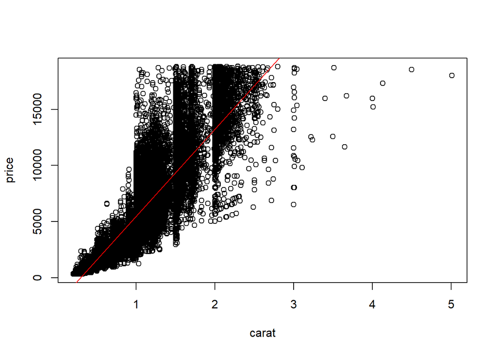

[interactive chart not shown]

```r
library(profvis)
profvis({
  data(diamonds, package = "ggplot2")

  plot(price ~ carat, data = diamonds)
  m <- lm(price ~ carat, data = diamonds)
  abline(m, col = "red")
})
```

### 1.3.1 Profiling time

```r
times <- 4e5
cols <- 150
data <-
 as.data.frame(x = matrix(rnorm(times * cols, mean = 5),
 ncol = cols))
data <- cbind(id = paste0("g", seq_len(times)), data)

profvis({
 # Store in another variable for this run
 data1 <- data

 # Get column means
 means <- apply(data1[, names(data1) != "id"], 2, mean)

 # Subtract mean from each column
 for (i in seq_along(means)) {
 data1[, names(data1) != "id"][, i] <-
 data1[, names(data1) != "id"][, i] - means[i]
 }
})
```

[interactive chart not shown]

```r
profvis({
  data1 <- data
  # Four different ways of getting column means
  means <- apply(data1[, names(data1) != "id"], 2, mean)
  means <- colMeans(data1[, names(data1) != "id"])
  means <- lapply(data1[, names(data1) != "id"], mean)
  means <- vapply(data1[, names(data1) != "id"], mean, numeric(1))
})
```

[interactive chart not shown]

```r
profvis({
 data1 <- data

 # Given a column, normalize values and return them
 col_norm <- function(col) {
 col - mean(col)
 }

 # Apply the normalizer function over all columns except id
 data1[, names(data1) != "id"] <-
   lapply(data1[, names(data1) != "id"], col_norm)
})
```

[interactive chart not shown]

### 1.3.2 Profiling memory

`Ví dụ này giải quyết một số vấn đề nâng cao hơn. Lần này, sẽ khó có thể nhìn trực tiếp nguyên nhân gây ra tình trạng chậm, nhưng sẽ có thể thấy một số tác dụng phụ của chúng, đáng chú ý nhất là tác dụng phụ từ việc phân bổ bộ nhớ với số lượng lớn.

Giả sử có một khung dữ liệu chứa một cột mà bạn muốn lấy tổng tích lũy (và bạn không biết về hàm tích lũy tích hợp sẵn của R). Đây là một cách để làm điều đó:

```r
profvis({
  data <- data.frame(value = runif(3e4))

  data$sum[1] <- data$value[1]
  for (i in seq(2, nrow(data))) {
    data$sum[i] <- data$sum[i-1] + data$value[i]
  }
})
```

[interactive chart not shown]

```r
profvis({
  csum <- function(x) {
    if (length(x) < 2) return(x)

    sum <- x[1]
    for (i in seq(2, length(x))) {
      sum[i] <- sum[i-1] + x[i]
    }
    sum
  }
  data$sum <- csum(data$value)
})
```

[interactive chart not shown]

# 2 HIỆN TƯỢNG ĐA CỘNG TUYẾN - MULTICOLLINEARITY

## 2.1 Đa cộng tuyến hoàn hảo (Exact Multicollinearity)

Hãy tạo một tập dữ liệu trong đó một trong những yếu tố dự đoán, $x_3$, là sự kết hợp tuyến tính của các yếu tố dự đoán khác.

```r
gen_exact_collin_data = function(num_samples = 100) {
  x1 = rnorm(n = num_samples, mean = 80, sd = 10)
  x2 = rnorm(n = num_samples, mean = 70, sd = 5)
  x3 = 2 * x1 + 4 * x2 + 3
  y = 3 + x1 + x2 + rnorm(n = num_samples, mean = 0, sd = 1)
  data.frame(y, x1, x2, x3)
}
```

Biến $y$ chỉ thực sự phụ thuộc vào $x_1$ và $x_2$.

```r
set.seed(42)
exact_collin_data = gen_exact_collin_data()
head(exact_collin_data)
```

```
##          y       x1       x2       x3
## 1 170.7135 93.70958 76.00483 494.4385
## 2 152.9106 74.35302 75.22376 452.6011
## 3 152.7866 83.63128 64.98396 430.1984
## 4 170.6306 86.32863 79.24241 492.6269
## 5 152.3320 84.04268 66.66613 437.7499
## 6 151.3155 78.93875 70.52757 442.9878
```

Điều gì xảy ra khi chúng ta cố gắng điều chỉnh mô hình hồi quy trong `R` bằng cách sử dụng tất cả các yếu tố dự đoán?

```r
exact_collin_fit = lm(y ~ x1 + x2 + x3, data = exact_collin_data)
summary(exact_collin_fit)
```

```
##
## Call:
## lm(formula = y ~ x1 + x2 + x3, data = exact_collin_data)
##
## Residuals:
##      Min       1Q   Median       3Q      Max
## -2.57662 -0.66188 -0.08253  0.63706  2.52057
##
## Coefficients: (1 not defined because of singularities)
##             Estimate Std. Error t value Pr(>|t|)
## (Intercept) 2.957336   1.735165   1.704   0.0915 .
## x1          0.985629   0.009788 100.702   <2e-16 ***
## x2          1.017059   0.022545  45.112   <2e-16 ***
## x3                NA         NA      NA       NA
## ---
## Signif. codes:  0 '***' 0.001 '**' 0.01 '*' 0.05 '.' 0.1 ' ' 1
##
## Residual standard error: 1.014 on 97 degrees of freedom
## Multiple R-squared:  0.9923, Adjusted R-squared:  0.9921
## F-statistic:  6236 on 2 and 97 DF,  p-value: < 2.2e-16
```

Chúng ta thấy rằng `R` chỉ quyết định loại trừ một biến. Tại sao chuyện này đang xảy ra?

```r
X = cbind(1, as.matrix(exact_collin_data[,-1]))
solve(t(X) %*% X)
```

Nếu tính toán $\boldsymbol{\hat{\beta}}$ using $\left( \boldsymbol{X}^T \boldsymbol{X} \right)^{-1}$, thì sẽ không khả thi, do thực tế các cột $\boldsymbol{X}$ là phụ thuộc tuyến tính. Đoạn code trến sẽ bị lỗi.

Khi điều này xảy ra, chúng tôi nói rằng có đa cộng tuyến trong tập dữ liệu.

Do vấn đề này, về cơ bản `R` đã chọn phù hợp với mô hình `y ~ x1 + x2`. Tuy nhiên, hãy lưu ý rằng hai mô hình khác sẽ có độ vừa vặn tương tự.

```r
fit1 = lm(y ~ x1 + x2, data = exact_collin_data)
fit2 = lm(y ~ x1 + x3, data = exact_collin_data)
fit3 = lm(y ~ x2 + x3, data = exact_collin_data)
```

```r
all.equal(fitted(fit1), fitted(fit2))
```

```
## [1] TRUE
```

```r
all.equal(fitted(fit2), fitted(fit3))
```

```
## [1] TRUE
```

Mặc dù các giá trị được trang bị của chúng đều giống nhau nhưng các hệ số ước tính của chúng rất khác nhau. Dấu của $x_2$ được chuyển đổi trong hai mô hình! Vì vậy, chỉ `fit1` đúng *giải thích* mối quan hệ giữa các biến, `fit2` và `fit3` vẫn *dự đoán* cũng như `fit1`, mặc dù các hệ số có rất ít hoặc không có ý nghĩa gì, một khái niệm mà chúng ta sẽ quay lại sau.

```r
coef(fit1)
```

```
## (Intercept)          x1          x2
##   2.9573357   0.9856291   1.0170586
```

```r
coef(fit2)
```

```
## (Intercept)          x1          x3
##   2.1945418   0.4770998   0.2542647
```

```r
coef(fit3)
```

```
## (Intercept)          x2          x3
##   1.4788921  -0.9541995   0.4928145
```

## 2.2 Đa cộng tuyến không hoàn hảo (imperfect multicollinearity)

Đa cộng tuyến không hoàn hảo (imperfect multicollinearity) xảy ra trong phân tích hồi quy tuyến tính khi có sự tương quan mạnh giữa các biến độc lập (predictor variables) trong mô hình, nhưng không hoàn toàn tương quan Trong trường hợp này, tương quan giữa các biến không làm cho ma trận hiệp phương sai (covariance matrix) của chúng trở nên đầy đủ đầy, nhưng vẫn có mức độ tương quan đủ lớn để gây ra một số vấn đề trong quá trình ước tính và đánh giá mô hình hồi quy.

Cộng tuyến chính xác là một ví dụ cực đoan về **cộng tuyến**, xảy ra trong hồi quy bội khi các biến dự báo có mối tương quan cao. Cộng tuyến thường được gọi là *đa cộng tuyến*, vì đây là hiện tượng thực sự chỉ xảy ra trong quá trình hồi quy bội.

Nhìn vào tập dữ liệu `seatpos` từ gói `faraway`, chúng ta sẽ thấy một ví dụ về khái niệm này. Các yếu tố dự đoán trong tập dữ liệu này là các thuộc tính khác nhau của người lái xe ô tô, chẳng hạn như chiều cao, cân nặng và tuổi tác của họ. Biến phản hồi `hipcenter` đo “khoảng cách theo chiều ngang của điểm giữa hông từ một vị trí cố định trong xe tính bằng mm.” Về cơ bản, nó đo vị trí ghế của một người lái xe nhất định. Đây có thể là thông tin hữu ích cho các nhà sản xuất ô tô khi cân nhắc sự thoải mái và an toàn khi thiết kế phương tiện.

Chúng tôi sẽ cố gắng điều chỉnh một mô hình dự đoán `hipcenter`. Hai biến dự đoán ngay lập tức khiến chúng tôi quan tâm: `HtShoes` và `Ht`. Chúng tôi chắc chắn mong đợi chiều cao của một người có mối tương quan chặt chẽ với chiều cao của họ khi đi giày. Chúng ta sẽ đặc biệt chú ý đến hai biến này khi điều chỉnh mô hình.

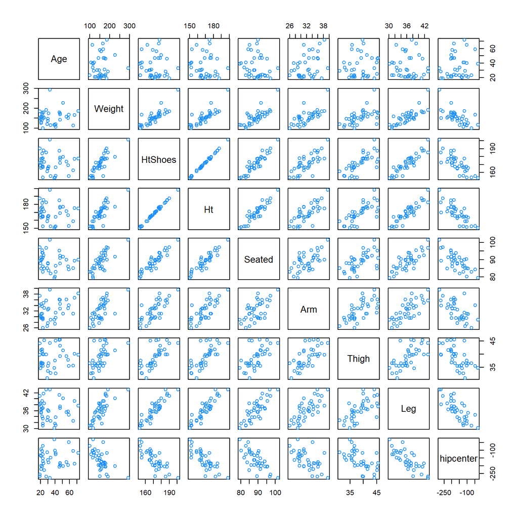

```r
library(faraway)
pairs(seatpos, col = "dodgerblue")
```

```r
round(cor(seatpos), 2)
```

```
##             Age Weight HtShoes    Ht Seated   Arm Thigh   Leg hipcenter
## Age        1.00   0.08   -0.08 -0.09  -0.17  0.36  0.09 -0.04      0.21
## Weight     0.08   1.00    0.83  0.83   0.78  0.70  0.57  0.78     -0.64
## HtShoes   -0.08   0.83    1.00  1.00   0.93  0.75  0.72  0.91     -0.80
## Ht        -0.09   0.83    1.00  1.00   0.93  0.75  0.73  0.91     -0.80
## Seated    -0.17   0.78    0.93  0.93   1.00  0.63  0.61  0.81     -0.73
## Arm        0.36   0.70    0.75  0.75   0.63  1.00  0.67  0.75     -0.59
## Thigh      0.09   0.57    0.72  0.73   0.61  0.67  1.00  0.65     -0.59
## Leg       -0.04   0.78    0.91  0.91   0.81  0.75  0.65  1.00     -0.79
## hipcenter  0.21  -0.64   -0.80 -0.80  -0.73 -0.59 -0.59 -0.79      1.00
```

Sau khi tải gói `faraway`, chúng tôi thực hiện một số kiểm tra nhanh về mối tương quan giữa các yếu tố dự đoán. Về mặt trực quan, chúng ta có thể thực hiện việc này bằng hàm `pairs()`, hàm này vẽ tất cả các biểu đồ phân tán có thể có giữa các cặp biến trong tập dữ liệu.

Chúng ta cũng có thể thực hiện điều này bằng số với hàm `cor()`, khi áp dụng cho tập dữ liệu, sẽ trả về tất cả các mối tương quan theo cặp. Lưu ý đây là ma trận đối xứng. Hãy nhớ lại rằng mối tương quan đo lường cường độ và hướng của mối quan hệ tuyến tính giữa hai biến. Mối tương quan giữa `Ht` và `HtShoes` là cực kỳ cao. Cao đến mức được làm tròn đến hai chữ số thập phân, nó dường như là 1!

Không giống như cộng tuyến chính xác, ở đây chúng ta vẫn có thể điều chỉnh một mô hình với tất cả các yếu tố dự đoán, nhưng điều này có ảnh hưởng gì?

```r
hip_model = lm(hipcenter ~ ., data = seatpos)
summary(hip_model)
```

```
##
## Call:
## lm(formula = hipcenter ~ ., data = seatpos)
##
## Residuals:
##     Min      1Q  Median      3Q     Max
## -73.827 -22.833  -3.678  25.017  62.337
##
## Coefficients:
##              Estimate Std. Error t value Pr(>|t|)
## (Intercept) 436.43213  166.57162   2.620   0.0138 *
## Age           0.77572    0.57033   1.360   0.1843
## Weight        0.02631    0.33097   0.080   0.9372
## HtShoes      -2.69241    9.75304  -0.276   0.7845
## Ht            0.60134   10.12987   0.059   0.9531
## Seated        0.53375    3.76189   0.142   0.8882
## Arm          -1.32807    3.90020  -0.341   0.7359
## Thigh        -1.14312    2.66002  -0.430   0.6706
## Leg          -6.43905    4.71386  -1.366   0.1824
## ---
## Signif. codes:  0 '***' 0.001 '**' 0.01 '*' 0.05 '.' 0.1 ' ' 1
##
## Residual standard error: 37.72 on 29 degrees of freedom
## Multiple R-squared:  0.6866, Adjusted R-squared:  0.6001
## F-statistic:  7.94 on 8 and 29 DF,  p-value: 1.306e-05
```

Một trong những điều đầu tiên chúng ta nên chú ý là phép thử $F$ test đối với hồi quy cho chúng ta biết rằng hồi quy là đáng kể, tuy nhiên mỗi yếu tố dự đoán riêng lẻ thì không. Một kết quả thú vị khác là dấu trái ngược của các hệ số của `Ht` và `HtShoes`. Điều này có vẻ khá phản trực giác. Tăng `Ht` làm tăng `hipcenter`, nhưng tăng `HtShoes` làm giảm `hipcenter`?

Điều này xảy ra do các yếu tố dự đoán có mối tương quan cao. Ví dụ: biến `HtShoe` giải thích phần lớn biến thể trong `Ht`. Khi cả hai đều có trong mô hình, tác động của chúng lên phản ứng sẽ giảm đi một cách riêng lẻ, nhưng chúng cùng nhau giải thích một phần lớn sự biến đổi của `hipcenter`.

Xác định $R_j^2$ là tỷ lệ của biến thể quan sát được trong biến dự đoán thứ $j$-được giải thích bởi các biến dự đoán khác. Nói cách khác, $R_j^2$ là bội số R-Squared cho hồi quy của $x_j$ trên mỗi biến dự đoán khác.

```r
ht_shoes_model = lm(HtShoes ~ . - hipcenter, data = seatpos)
summary(ht_shoes_model)$r.squared
```

```
## [1] 0.9967472
```

[output not shown]

Ví dụ, trong mô hình hồi qui của việc tiêu thụ điện theo thu nhập (X_2) và kích thước nhà ở (X_3) có một ràng buộc cụ thể về tổng thể, trong đó các gia đình có thu nhập cao hơn nói chung ở nhà lớn hơn các gia đình có thu nhập thấp hơn. 3. Chọn biến X_i có độ biến thiên nhỏ.

## 2.3 Phát hiện đa cộng tuyến

1. R^2 cao (trên 0.8) và thống kê t trong bảng Coefficients thấp
2. Hệ số phóng đại phương sai VIF (Variance inflation factor) để xác định mối tương quan giữa các biến độc lập và sức mạnh của mối tương quan đó. Giá trị VIF bắt đầu từ 1 và không có giới hạn trên.

Giá trị VIF trong khoảng từ 1-2 chỉ ra rằng không có mối tương quan giữa biến độc lập này và bất kỳ biến nào khác. VIF giữa 2 và 5 cho thấy rằng có một mối tương quan vừa phải, nhưng nó không đủ nghiêm trọng để người nghiên cứu phải tìm biện pháp khắc phục. VIF lớn hơn 5, mối tương quan cao, các giá trị p - values là đáng nghi ngờ. VIF > 10 thì chắc chắn xảy ra đa cộng tuyến.

## 2.4 Biện pháp khắc phục

• Loại bỏ một số biến độc lập có tương quan cao • Bổ sung dữ liệu hoặc tìm thêm những dữ liệu mới, tăng cỡ mẫu, tìm mẫu dữ liệu khá

• Thực hiện phân tích riêng các biến có tương quan cao • Các kỹ thuật thống kê đa biến như phân tích nhân tố (factor analysis) và các thành tố cơ bản (principal components) hoặc các kỹ thuật như hồi qui dạng sóng (ridge regression)

### 2.4.1 Variance Inflation Factor.

Công thức $\hat{\beta_j}$ được viết bởi

$$\text{Var}(\hat{\beta_j}) = \sigma^2 C_{jj} = \sigma^2 \left( \frac{1}{1
- R_j^2} \right) \frac{1}{S_{x_j x_j}}$$

khi

$$S_{x_j x_j} = \sum(x_{ij}-\bar{x}_j)^2.$$

Điều này cho thấy một cách để hiểu sự cộng tuyến ảnh hưởng như thế nào đến ước tính hồi quy

$$\frac{1}{1 - R_j^2}$$

Hàm `vif` từ gói `faraway` tính toán VIF cho từng yếu tố dự đoán của một mô hình.

```r
vif(hip_model)
```

```
##        Age     Weight    HtShoes         Ht     Seated        Arm      Thigh
##   1.997931   3.647030 307.429378 333.137832   8.951054   4.496368   2.762886
##        Leg
##   6.694291
```

Trong thực tế, người ta thường nói rằng bất kỳ VIF nào lớn hơn $5$ đều là nguyên nhân gây lo ngại. Vì vậy, trong ví dụ này, chúng ta thấy có một vấn đề đa cộng tuyến rất lớn vì nhiều yếu tố dự đoán có VIF lớn hơn 5.

Chúng ta hãy nghiên cứu sâu hơn xem sự hiện diện của cộng tuyến thực sự ảnh hưởng như thế nào đến một mô hình. Nếu chúng ta thêm một lượng nhiễu vừa phải vào dữ liệu, chúng ta sẽ thấy rằng ước tính của các hệ số thay đổi đáng kể. Đây là một tác dụng khá không mong muốn. Việc thêm nhiễu ngẫu nhiên sẽ không ảnh hưởng đến các hệ số của mô hình.

```r
set.seed(1337)
noise = rnorm(n = nrow(seatpos), mean = 0, sd = 5)
hip_model_noise = lm(hipcenter + noise ~ ., data = seatpos)
```

Thêm “nhiễu” có tác động lớn như vậy, dấu của hệ số `Ht` đã thay đổi.

```r
coef(hip_model)
```

```
##  (Intercept)          Age       Weight      HtShoes           Ht       Seated
## 436.43212823   0.77571620   0.02631308  -2.69240774   0.60134458   0.53375170
##          Arm        Thigh          Leg
##  -1.32806864  -1.14311888  -6.43904627
```

```r
coef(hip_model_noise)
```

```
##  (Intercept)          Age       Weight      HtShoes           Ht       Seated
## 415.32909380   0.76578240   0.01910958  -2.90377584  -0.12068122   2.03241638
##          Arm        Thigh          Leg
##  -1.02127944  -0.89034509  -5.61777220
```

Điều này cho chúng ta biết rằng một mô hình có cộng tuyến rất tệ trong việc giải thích mối quan hệ giữa phản ứng và các yếu tố dự đoán. Chúng tôi thậm chí không thể tự tin vào hướng đi của mối quan hệ. Tuy nhiên, sự cộng tác có ảnh hưởng đến dự đoán không?

Intercept (Hệ số chặn): Intercept thể hiện giá trị của biến phụ thuộc khi tất cả các biến độc lập đều bằng 0. Trong trường hợp này, giá trị Intercept là 436.43212823. Nếu không có biến độc lập nào được xem xét (tất cả đều bằng 0), thì giá trị của biến phụ thuộc sẽ bằng 436.43212823.

Age (Tuổi): Hệ số này là 0.77571620. Điều này có nghĩa rằng với mỗi đơn vị tăng trong biến Age, giá trị của biến phụ thuộc sẽ tăng khoảng 0.7757 đơn vị (điều này giả định mối quan hệ tuyến tính giữa Age và biến phụ thuộc).

Weight (Cân nặng): Hệ số này là 0.02631308. Với mỗi đơn vị tăng trong biến Weight, giá trị của biến phụ thuộc sẽ tăng khoảng 0.0263 đơn vị.

HtShoes (Chiều cao với giày): Hệ số này là -2.69240774. Với mỗi đơn vị tăng trong biến HtShoes, giá trị của biến phụ thuộc sẽ giảm khoảng 2.6924 đơn vị. Hệ số âm cho thấy mối quan hệ nghịch với biến này.

Ht (Chiều cao): Hệ số này là 0.60134458. Với mỗi đơn vị tăng trong biến Ht, giá trị của biến phụ thuộc sẽ tăng khoảng 0.6013 đơn vị.

Seated (Chiều cao ngồi): Hệ số này là 0.53375170. Với mỗi đơn vị tăng trong biến Seated, giá trị của biến phụ thuộc sẽ tăng khoảng 0.5338 đơn vị.

Arm (Chân tay): Hệ số này là -1.32806864. Với mỗi đơn vị tăng trong biến Arm, giá trị của biến phụ thuộc sẽ giảm khoảng 1.3281 đơn vị. Hệ số âm cho thấy mối quan hệ nghịch với biến này.

Thigh (Đùi): Hệ số này là -1.14311888. Với mỗi đơn vị tăng trong biến Thigh, giá trị của biến phụ thuộc sẽ giảm khoảng 1.1431 đơn vị. Hệ số âm cho thấy mối quan hệ nghịch với biến này.

Leg (Chân): Hệ số này là -6.43904627. Với mỗi đơn vị tăng trong biến Leg, giá trị của biến phụ thuộc sẽ giảm khoảng 6.4390 đơn vị. Hệ số âm cho thấy mối quan hệ nghịch với biến này.

Tóm lại, đoạn phân tích này cung cấp thông tin về cách mỗi biến độc lập ảnh hưởng đến biến phụ thuộc trong mô hình tuyến tính. Các hệ số cho biết hướng và mức độ ảnh hưởng của từng biến đối với biến phụ thuộc.

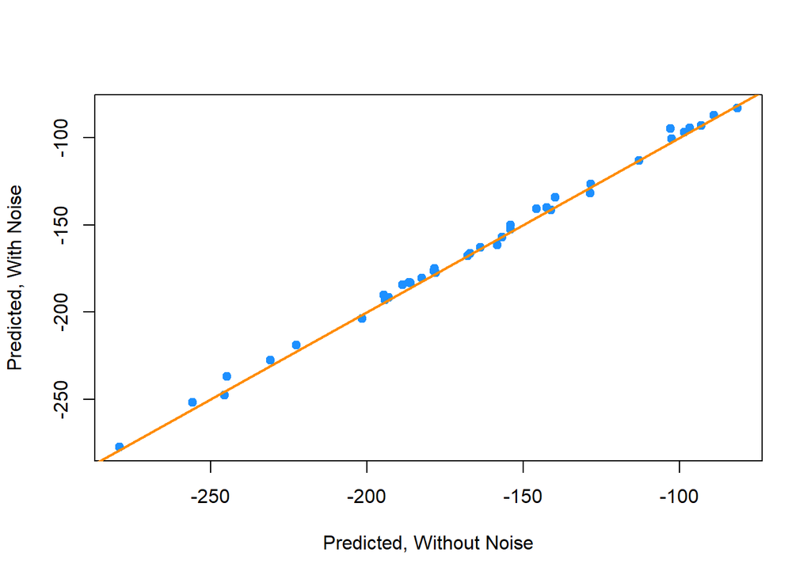

```r
plot(fitted(hip_model), fitted(hip_model_noise), col = "dodgerblue", pch = 20,
     xlab = "Predicted, Without Noise", ylab = "Predicted, With Noise", cex = 1.5)
abline(a = 0, b = 1, col = "darkorange", lwd = 2)
```

Chúng tôi thấy rằng bằng cách vẽ các giá trị dự đoán bằng cách sử dụng cả hai mô hình với nhau, chúng thực sự khá giống nhau.

Bây giờ chúng ta hãy xem một mô hình nhỏ hơn,

```r
hip_model_small = lm(hipcenter ~ Age + Arm + Ht, data = seatpos)
summary(hip_model_small)
```

```
##
## Call:
## lm(formula = hipcenter ~ Age + Arm + Ht, data = seatpos)
##
## Residuals:
##     Min      1Q  Median      3Q     Max
## -82.347 -24.745  -0.094  23.555  58.314
##
## Coefficients:
##             Estimate Std. Error t value Pr(>|t|)
## (Intercept) 493.2491   101.0724   4.880 2.46e-05 ***
## Age           0.7988     0.5111   1.563  0.12735
## Arm          -2.9385     3.5210  -0.835  0.40979
## Ht           -3.4991     0.9954  -3.515  0.00127 **
## ---
## Signif. codes:  0 '***' 0.001 '**' 0.01 '*' 0.05 '.' 0.1 ' ' 1
##
## Residual standard error: 36.12 on 34 degrees of freedom
## Multiple R-squared:  0.6631, Adjusted R-squared:  0.6333
## F-statistic:  22.3 on 3 and 34 DF,  p-value: 3.649e-08
```

```r
vif(hip_model_small)
```

```
##      Age      Arm       Ht
## 1.749943 3.996766 3.508693
```

```r
anova(hip_model_small, hip_model)
```

```
## Analysis of Variance Table
##
## Model 1: hipcenter ~ Age + Arm + Ht
## Model 2: hipcenter ~ Age + Weight + HtShoes + Ht + Seated + Arm + Thigh +
##     Leg
##   Res.Df   RSS Df Sum of Sq      F Pr(>F)
## 1     34 44354
## 2     29 41262  5    3091.9 0.4346 0.8207
```

Sử dụng $F$-test để so sánh 2 mô hình, ưu tiên chọn mô hình nhỏ hơn

```r
ht_shoes_model_small = lm(HtShoes ~ Age + Arm + Ht, data = seatpos)
```

Mối tương quan của hai phần dư này mang lại cho chúng ta **hệ số tương quan từng phần** (**partial correlation coefficient**) của `HtShoes` và `hipcenter` với các ảnh hưởng của `Tuổi`, `Arm` và `Ht` đã bị loại bỏ.

```r
cor(resid(ht_shoes_model_small), resid(hip_model_small))
```

```
## [1] -0.03311061
```

Vì giá trị này nhỏ, gần bằng 0 nên có nghĩa là biến thể của `hipcenter` không được giải thích bởi `Tuổi`, `Arm` và `Ht` cho thấy rất ít mối tương quan với biến thể của `HtShoes` không được giải thích bởi `Tuổi`, `Arm` và `Ht`. Do đó việc thêm `HtShoes` vào mô hình có thể sẽ mang lại rất ít lợi ích.

Tương tự, một **biểu đồ được thêm vào có thể thay đổi** trực quan hóa các phần dư này với nhau. Cũng rất hữu ích khi hồi quy phần dư của phản hồi so với phần dư của yếu tố dự đoán và thêm đường hồi quy vào biểu đồ.

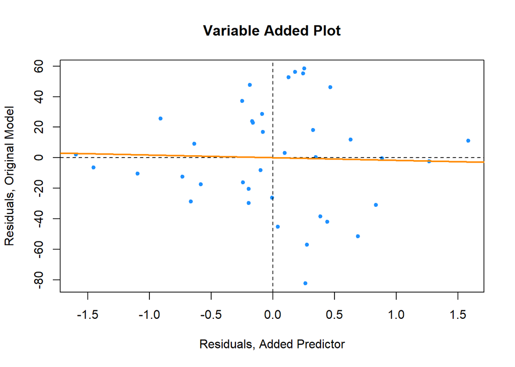

```r
plot(resid(hip_model_small) ~ resid(ht_shoes_model_small),
     col = "dodgerblue", pch = 20,
     xlab = "Residuals, Added Predictor",
     ylab = "Residuals, Original Model",
     main = "Variable Added Plot")
abline(h = 0, lty = 2)
abline(v = 0, lty = 2)
abline(lm(resid(hip_model_small) ~ resid(ht_shoes_model_small)),
       col = "darkorange", lwd = 2)
```

Ở đây biểu đồ được thêm vào biến thể hiện hầu như không có mối quan hệ tuyến tính. Điều này biết rằng việc thêm `HtShoes` vào mô hình có thể sẽ không có giá trị. Vì sự biến thiên của nó phần lớn được giải thích bởi các yếu tố dự đoán khác nên việc thêm nó vào mô hình sẽ không giúp cải thiện mô hình nhiều. Tuy nhiên, nó sẽ làm tăng sự biến thiên của các ước tính và làm cho mô hình khó diễn giải hơn nhiều.

# 3 MISSING DATA

## 3.1 GENERAL METHOD

### 3.1.1 Listwise detection

### 3.1.2 Pairwise detection

### 3.1.3 Mean/median imputation

$$(x - mu)/n$$

### 3.1.4 Regression imputation

### 3.1.5 Stochastic regression imputation

### 3.1.6 LOCF and BOFC

### 3.1.7 Indicator method

### 3.1.8 Gower’s method (kNN)

## 3.2 Multiple imputation

### 3.2.1 Chuẩn bị dữ liệu

Bộ dữ liệu sleep trong package “VIM” được chọn để minh họa cho chủ đề này.

```r
library(VIM)
library(mice)
data(sleep, package="VIM")
head(sleep)
```

```
##    BodyWgt BrainWgt NonD Dream Sleep Span Gest Pred Exp Danger
## 1 6654.000   5712.0   NA    NA   3.3 38.6  645    3   5      3
## 2    1.000      6.6  6.3   2.0   8.3  4.5   42    3   1      3
## 3    3.385     44.5   NA    NA  12.5 14.0   60    1   1      1
## 4    0.920      5.7   NA    NA  16.5   NA   25    5   2      3
## 5 2547.000   4603.0  2.1   1.8   3.9 69.0  624    3   5      4
## 6   10.550    179.5  9.1   0.7   9.8 27.0  180    4   4      4
```

Dataset ‘sleep’ là bộ dữ liệu về giấc ngủ của một loài động vật có vú, gồm 62 cá thể và 10 biến số:

BodyWgt (Cân Nặng): Trọng lượng cơ thể của động vật.

BrainWgt (Cân Nặng Não): Trọng lượng của bộ não của động vật.

NonD (Ngủ Không Có Giấc Mơ): Thời gian mà động vật đã ngủ mà không có giấc mơ.

Dream (Ngủ Có Giấc Mơ): Thời gian mà động vật đã ngủ có giấc mơ.

Sleep (Tổng Thời Gian Ngủ): Tổng thời gian ngủ, bao gồm cả thời gian ngủ không có giấc mơ và thời gian ngủ có giấc mơ.

Span (Tuổi Thọ): Tuổi thọ của động vật.

Gest (Thời Gian Mang Thai): Thời gian mà động vật mang thai.

Pred (Chỉ Số Rủi Ro Do Săn Mồi): Chỉ số đánh giá mức độ rủi ro của động vật dựa trên hành vi săn mồi.

Exp (Chỉ Số Tiếp Xúc Khi Ngủ): Chỉ số đánh giá mức độ tiếp xúc của động vật khi đang ngủ.

Danger (Chỉ Số Nguy Hiểm Tổng Thể): Chỉ số đánh giá mức độ nguy hiểm của động vật.

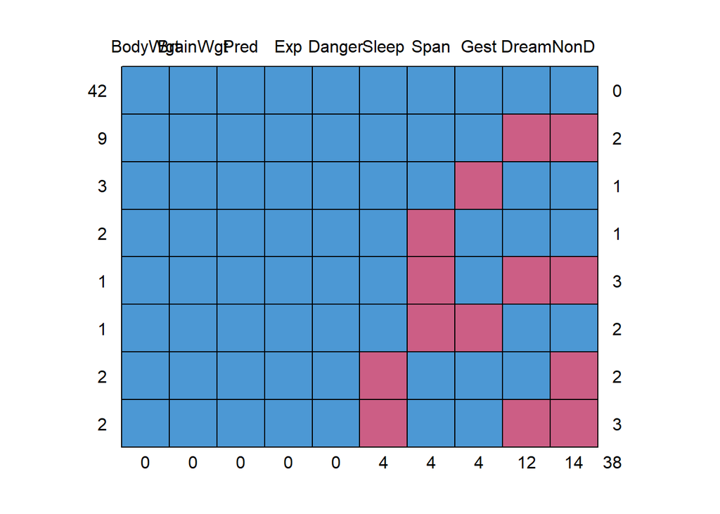

```
##    BodyWgt BrainWgt Pred Exp Danger Sleep Span Gest Dream NonD
## 42       1        1    1   1      1     1    1    1     1    1  0
## 9        1        1    1   1      1     1    1    1     0    0  2
## 3        1        1    1   1      1     1    1    0     1    1  1
## 2        1        1    1   1      1     1    0    1     1    1  1
## 1        1        1    1   1      1     1    0    1     0    0  3
## 1        1        1    1   1      1     1    0    0     1    1  2
## 2        1        1    1   1      1     0    1    1     1    0  2
## 2        1        1    1   1      1     0    1    1     0    0  3
##          0        0    0   0      0     4    4    4    12   14 38
```

```r
md.pattern(sleep)
```

Giá trị ‘1’ đại diện cho dữ liệu hoàn chỉnh, ‘0’ đại diện cho sự xuất hiện của giá trị NA. Cột đầu tiên thể hiện số lượng dòng chứa dữ liệu bên phải, còn cột cuối cùng thể hiện số lượng giá trị NA trong dòng tương ứng. Dòng cuối cùng dưới cùng cho biết tổng số lượng giá trị NA trong cột tương ứng ở trên.

Do đó, trong bảng dữ liệu, có 42 dòng không có giá trị NA, 2 dòng có 1 NA ở biến Span, 3 dòng có 1 NA ở biến Gest, và 9 dòng có 2 NA ở biến Dream và NonD. Tính từ dòng cuối cùng, tổng số giá trị NA trong cột sleep là 38, trong đó có 14 NA ở biến NonD, 12 NA ở biến Dream, và 4 NA ở biến Gest

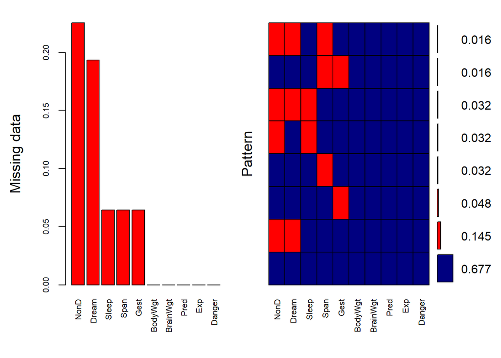

```
##
##  Variables sorted by number of missings:
##  Variable      Count
##      NonD 0.22580645
##     Dream 0.19354839
##     Sleep 0.06451613
##      Span 0.06451613
##      Gest 0.06451613
##   BodyWgt 0.00000000
##  BrainWgt 0.00000000
##      Pred 0.00000000
##       Exp 0.00000000
##    Danger 0.00000000
```

```r
aggr(sleep, col=c('navyblue','red'),
                  numbers=TRUE, sortVars=TRUE,
                  labels=names(sleep), cex.axis=.7,
                  gap=3, ylab=c("Missing data","Pattern"))
```

Màu đỏ đại diện cho giá trị NA, trong khi màu xanh biểu thị dữ liệu có sẵn. Biểu đồ bên trái thể hiện phần trăm của mỗi biến số có giá trị NA. Biểu đồ bên phải biểu diễn phần trăm của các trường hợp NA xuất hiện đồng thời giữa các biến số. Tổng cộng, chỉ có 67.7% dữ liệu không bị thiếu giá trị. Tỷ lệ thiếu là 32.3%, một con số đáng kể trong tập dữ liệu này.

Tỷ lệ thiếu giá trị khá lớn và có thể ảnh hưởng đáng kể đến khả năng phân tích dữ liệu. Vì vậy, việc xử lý giá trị NA một cách thích hợp là cần thiết để tận dụng tối đa thông tin từ tập dữ liệu này.

### 3.2.2 Thay thế dữ liệu thiếu

Phương pháp MICE giả sử rằng dữ liệu bị mất theo kiểu Missing at Random (MAR), có nghĩa là xác suất một giá trị bị mất chỉ phụ thuộc vào giá trị quan sát được và có thể dự đoán chúng dựa trên giá trị của các biến tương tự. Phương pháp này xác định dữ liệu bị mất dựa trên quy luật biến thiên của các biến trong tập dữ liệu.

Ví dụ: Giả sử có các biến X1, X2,… Xk. Nếu X1 có giá trị bị mất, chúng ta sẽ sử dụng các biến từ X2 đến Xk để dự đoán nó thông qua hồi quy. Các giá trị bị mất trong X1 sẽ được thay thế bằng giá trị dự đoán từ các biến khác. Tương tự, nếu X2 có giá trị bị mất, các biến X1, X3 đến Xk sẽ được sử dụng trong mô hình dự đoán như các biến độc lập, và sau đó giá trị bị mất sẽ được thay thế bằng giá trị dự đoán.

Mặc định, phương pháp này sử dụng hồi quy tuyến tính để dự đoán giá trị bị mất của biến liên tục và hồi quy logistic cho giá trị bị mất trong biến rời rạc. Khi quá trình hoàn tất, nhiều tập dữ liệu con được tạo ra, khác nhau chỉ ở các giá trị bị mất. Phương pháp này cho phép xây dựng mô hình trên các tập dữ liệu con riêng lẻ và kết hợp kết quả của chúng.

Cụ thể, MICE sử dụng các phương pháp như Predictive Mean Matching (PMM) cho biến liên tục, Logistic Regression cho biến nhị phân, hồi quy đa thức Bayesian cho biến factor, và mô hình tỷ lệ chênh cho biến có thứ tự. Đối với biến sleep, thực hiện thay thế NA cho các biến liên tục bằng phương pháp “pmm” với m = 5 (thực hiện 5 lần thay thế), sau đó chọn ra tập con chứa giá trị bị mất quan trọng.

```r
imputed_Data <- mice(sleep, m=5, maxit = 50, method = 'pmm', seed = 500, PROP=T, print=FALSE)
head(imputed_Data)
```

```
## $data
##     BodyWgt BrainWgt NonD Dream Sleep  Span  Gest Pred Exp Danger
## 1  6654.000  5712.00   NA    NA   3.3  38.6 645.0    3   5      3
## 2     1.000     6.60  6.3   2.0   8.3   4.5  42.0    3   1      3
## 3     3.385    44.50   NA    NA  12.5  14.0  60.0    1   1      1
## 4     0.920     5.70   NA    NA  16.5    NA  25.0    5   2      3
## 5  2547.000  4603.00  2.1   1.8   3.9  69.0 624.0    3   5      4
## 6    10.550   179.50  9.1   0.7   9.8  27.0 180.0    4   4      4
## 7     0.023     0.30 15.8   3.9  19.7  19.0  35.0    1   1      1
## 8   160.000   169.00  5.2   1.0   6.2  30.4 392.0    4   5      4
## 9     3.300    25.60 10.9   3.6  14.5  28.0  63.0    1   2      1
## 10   52.160   440.00  8.3   1.4   9.7  50.0 230.0    1   1      1
## 11    0.425     6.40 11.0   1.5  12.5   7.0 112.0    5   4      4
## 12  465.000   423.00  3.2   0.7   3.9  30.0 281.0    5   5      5
## 13    0.550     2.40  7.6   2.7  10.3    NA    NA    2   1      2
```

[output cut: 233 more lines]

```r
completeData <- complete(imputed_Data,action=1)
head(completeData)
```

```
##    BodyWgt BrainWgt NonD Dream Sleep Span Gest Pred Exp Danger
## 1 6654.000   5712.0  2.1   1.4   3.3 38.6  645    3   5      3
## 2    1.000      6.6  6.3   2.0   8.3  4.5   42    3   1      3
## 3    3.385     44.5 11.0   1.5  12.5 14.0   60    1   1      1
## 4    0.920      5.7 12.8   3.9  16.5  9.0   25    5   2      3
## 5 2547.000   4603.0  2.1   1.8   3.9 69.0  624    3   5      4
## 6   10.550    179.5  9.1   0.7   9.8 27.0  180    4   4      4
```

```r
mod_o = lm( Dream ~ BrainWgt + BodyWgt + Span + Gest + Pred + Exp, data=sleep)
summary(mod_o)
```

```
##
## Call:
## lm(formula = Dream ~ BrainWgt + BodyWgt + Span + Gest + Pred +
##     Exp, data = sleep)
##
## Residuals:
##     Min      1Q  Median      3Q     Max
## -1.9551 -0.5999 -0.3257  0.6629  3.5911
##
## Coefficients:
##               Estimate Std. Error t value Pr(>|t|)
## (Intercept)  3.8374634  0.4793253   8.006 1.35e-09 ***
## BrainWgt     0.0006457  0.0012805   0.504   0.6171
## BodyWgt      0.0003752  0.0021187   0.177   0.8604
## Span        -0.0198476  0.0167751  -1.183   0.2443
## Gest        -0.0045519  0.0022711  -2.004   0.0524 .
## Pred        -0.3192048  0.1824078  -1.750   0.0884 .
## Exp         -0.0706843  0.2214401  -0.319   0.7514
## ---
## Signif. codes:  0 '***' 0.001 '**' 0.01 '*' 0.05 '.' 0.1 ' ' 1
##
## Residual standard error: 1.129 on 37 degrees of freedom
##   (18 observations deleted due to missingness)
## Multiple R-squared:  0.4269, Adjusted R-squared:  0.334
## F-statistic: 4.594 on 6 and 37 DF,  p-value: 0.001405
```

```r
mod_i = lm( Dream ~ BrainWgt + BodyWgt + Span + Gest + Pred + Exp, data=completeData)
summary(mod_i)
```

```
##
## Call:
## lm(formula = Dream ~ BrainWgt + BodyWgt + Span + Gest + Pred +
##     Exp, data = completeData)
##
## Residuals:
##     Min      1Q  Median      3Q     Max
## -1.6852 -0.6060 -0.3026  0.4213  3.6711
##
## Coefficients:
##               Estimate Std. Error t value Pr(>|t|)
## (Intercept)  3.5705655  0.3859395   9.252 8.39e-13 ***
## BrainWgt     0.0011500  0.0006070   1.894   0.0634 .
## BodyWgt     -0.0005882  0.0005512  -1.067   0.2906
## Span        -0.0214263  0.0133409  -1.606   0.1140
## Gest        -0.0036322  0.0020145  -1.803   0.0769 .
## Pred        -0.1592931  0.1415904  -1.125   0.2655
## Exp         -0.2103508  0.1612447  -1.305   0.1975
## ---
## Signif. codes:  0 '***' 0.001 '**' 0.01 '*' 0.05 '.' 0.1 ' ' 1
##
## Residual standard error: 1.118 on 55 degrees of freedom
## Multiple R-squared:  0.3964, Adjusted R-squared:  0.3305
## F-statistic:  6.02 on 6 and 55 DF,  p-value: 6.871e-05
```

# 4 OUTLIER DETECTION

## 4.1 Dectection via visualization

### 4.1.1 Visualize by R

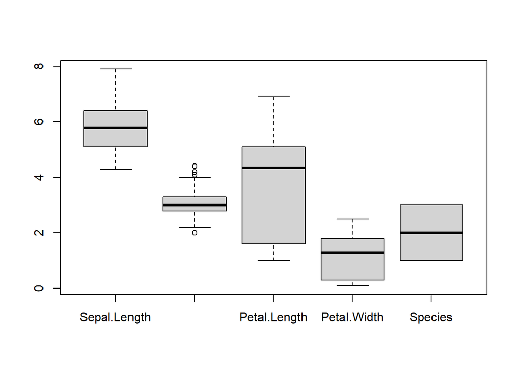

```r
boxplot(iris)
```

### 4.1.2 Using ggplot2 package

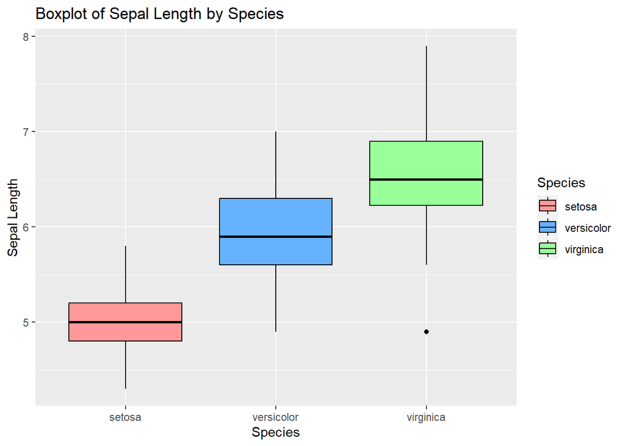

```r
ggplot(iris, aes(x = Species, y = Sepal.Length, fill = Species)) +
  geom_boxplot(color = "black", notch = FALSE) +
  scale_fill_manual(values = c("#FF9999", "#66B2FF", "#99FF99")) +
  labs(title = "Boxplot of Sepal Length by Species",
       x = "Species",
       y = "Sepal Length")
```

## 4.2 Outliers, Leverage và Influential point

Khái niệm outlier đề cập đến các điểm dữ liệu sai lệch đáng kể so với dữ liệu thông thường. Các quan sát có phần dư chuẩn hóa lớn là các giá trị ngoại lệ trong biến phụ thuộc vì chúng nằm xa phương trình hồi quy theo hướng Y.

Những đối tượng như vậy có thể được suy ra dựa trên thước đo phù hợp về độ lệch của chúng. Outlier thường có giá trị rất cao hoặc rất thấp so với giá trị trung bình của tập dữ liệu, và nó có thể tạo ra ảnh hưởng không mong muốn đến quá trình phân tích thống kê.

Outliers có thể xuất hiện do các lỗi khi thực hiện thu thập số liệu (trong trường hợp đó, chúng cần được loại bỏ) hoặc chúng chỉ là những trường hợp không thể giải thích được bằng mô hình nhưng lại mang thông tin quan trọng. Outliers có thể nằm trong không gian x, không gian y hoặc cả hai.

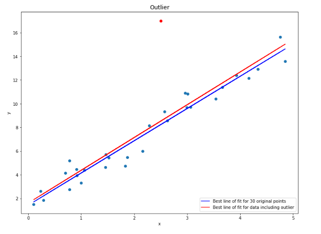

Outlier

Điểm đòn bẩy (Leverage point) có giá trị cực đại hoặc cực tiểu đối với các biến ngoại sinh (biến độc lập x).

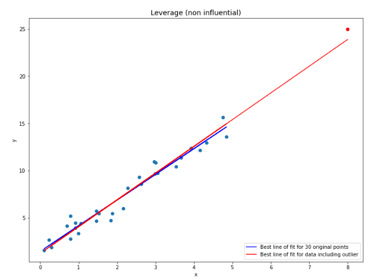

Leverage

Điểm ảnh hưởng (Influential point) là điểm có tác động lớn đến mô hình hồi quy, chẳng hạn như các kết quả dự báo, độ dốc hoặc kết quả kiểm tra giả thuyết. Các quan sát có ảnh hưởng thường là các ngoại lệ trong biến Y hoặc biến X (không gian X).

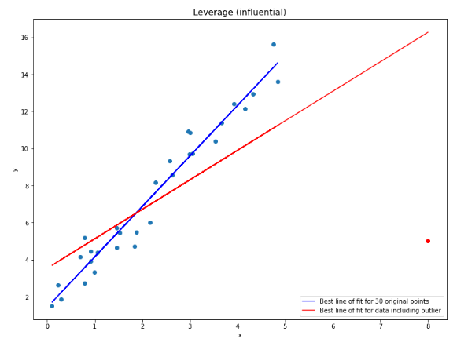

Influential